# Caseum

Introducing a lightweight approach to software architecture

Leo Simons

# Introduction

## Key concepts

- **Multiple views:**
  - Use C4 for component diagrams
  - Include other views for other important information
- **Lightweight approach:**
  - Don’t use a digital diagram when a whiteboard picture will do
  - If you do need structured models, use lightweight text-based syntax
  - Focus on interactions over processes and tools
- **User-centric:**
  - Include UI designs since they help users understand
  - Include Actor personas and scenarios since they drive the design
  - Events are a good way for users to understand systems
- **Standardise common best practices:**
  - Embeds established practices like Event Storming and Domain-Driven Design
  - Agile development context expected

## Architecture = communication

**Use simple, accessible tools:**

- Architecture records design decisions
- Designs are recorded for people working on and with the software
- Prefer tools that untrained non-technical people can use
- Slack & Email over Documents
- Wiki/SharePoint over Version Control
- Readable text files over Formal Methods

[figure not shown]

# 3 Stages

## Lightweight approach

**Three stages as projects get bigger:**

1. Brainstorming & whiteboarding
2. Digital diagrams & decision records
3. Models as code & executable specifications

…use only what you really need.

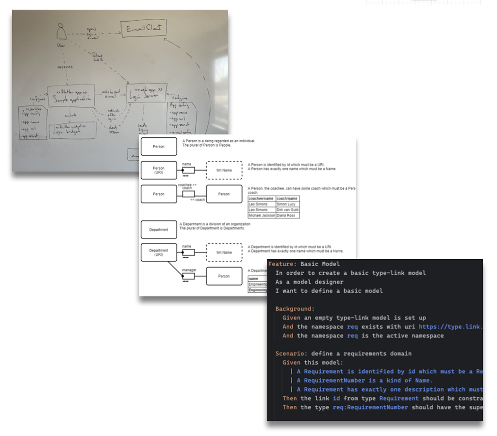

## Stage 1: whiteboarding

**Design is an activity: draw again and again**

- Draw the software design on a whiteboard using multiple different views
- Take pictures of the whiteboard and add them to decision records
- Drawing a picture while talking about it is a powerful way to share designs
- Caseum shows how to draw different views on the whiteboard

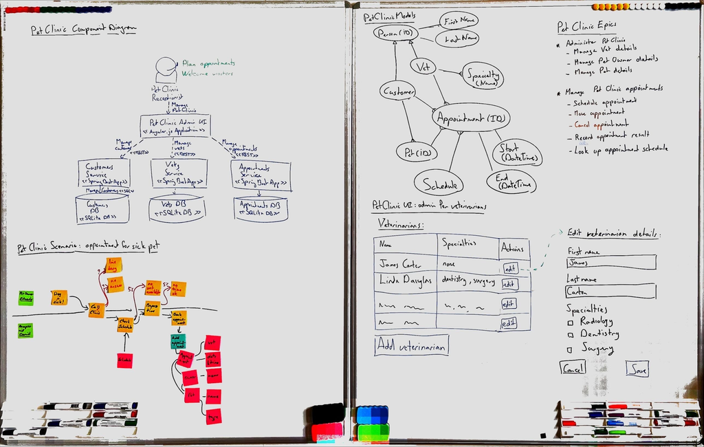

## Stage 2: digital diagrams

**Use draw.io for high quality visuals**

- When whiteboarding stops working…
- Create high-fidelity digital versions of the different Caseum views
- Use the draw.io libraries and templates Caseum provides
- Start keeping a digital record of your design decisions
- Use the simplest and most accessible digital tools so everyone can contribute to the design

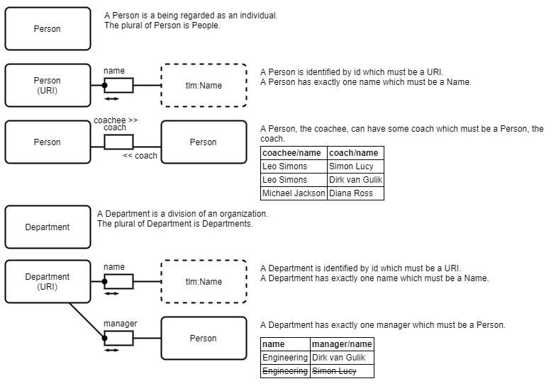

## Stage 3: models as code

**Create structured text versions of views**

- Overkill for most projects
- Especially if you have modular architecture & independent teams
- When investing in codifying your architecture, focus on gaining back other benefits, such as
- Automated testing
- Generating code and docs
- API contracts

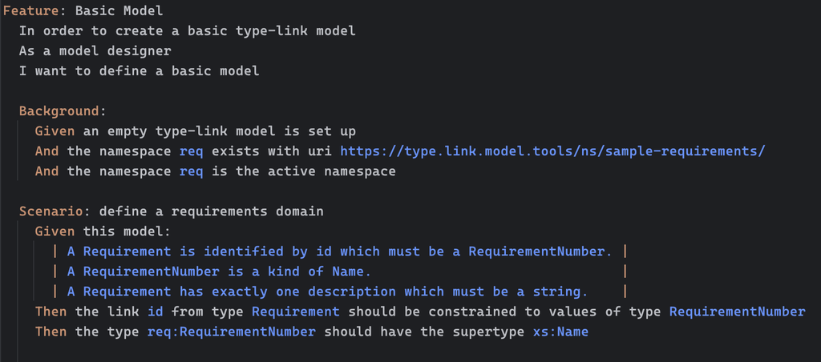

# 6 Views

## The 6 views in Caseum

**Caseum is a mnemonic:**

- **C**omponents using C4
- **A**ctors using roles
- **S**tories using Gherkin
- **E**vents using event storming
- **U**I using wireframes
- **M**odels using facts

[figure not shown]

## Actors

**Caseum adopts role descriptions for the key actors**

- Having a clear picture of your users in mind helps to make software accessible
- Deciding on your key users may be hard but helps to build the right thing
- Always capture at least the role (or system) **name** and their key **need** from the software you are designing

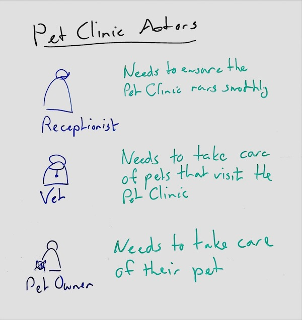

## Stories

**Caseum adopts user stories for functionality**

- Describing functionality with and in the language of your users helps to make software that is useful
- Write just enough detail so everyone involved understands what is needed and add other Caseum views for more detail
- Implementing software one user story at a time is sometimes an option but Caseum does not recommend it

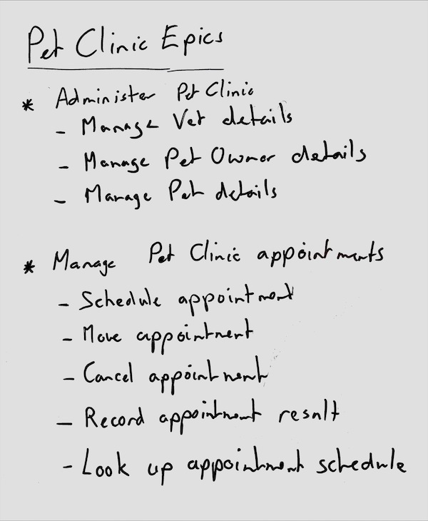

## UI

**Caseum adopts wireframes for the user interface**

- Talking through how the UI will look and function with users and stakeholders helps clarify the other views
- Because wireframes limit detail they are easier to discuss and change
- Involve skilled UI/UX designers when possible

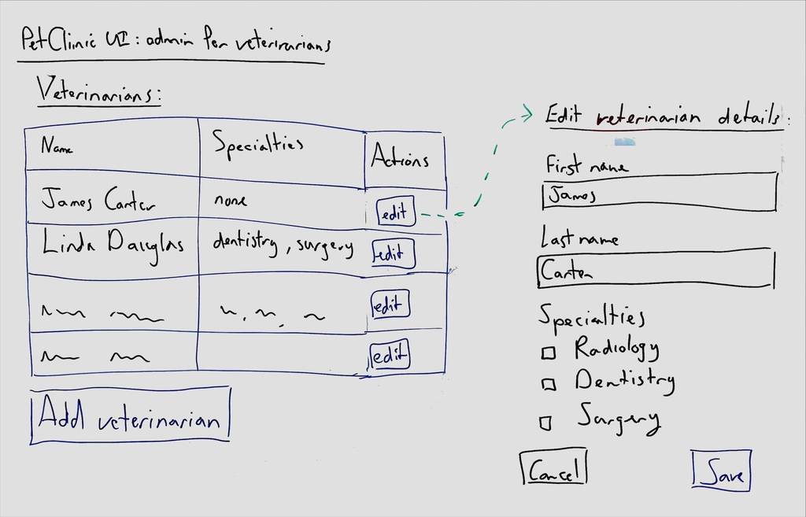

## Events

**Caseum adopts Event Storming for business domain events**

- Talking through the processes that software supports is a great way for developers to gain understanding of the business domain
- Having the whole process in one picture helps to make good choices for how to break large systems into pieces (by “bounded context”)

[figure not shown]

## Components

**Caseum adopts C4 for components**

- Focus on telling the story of your architecture over following the C4 model exactly
- The context and component diagrams are the most important, container diagrams can come later
- Avoid structurizr / models-as-code as long as you can

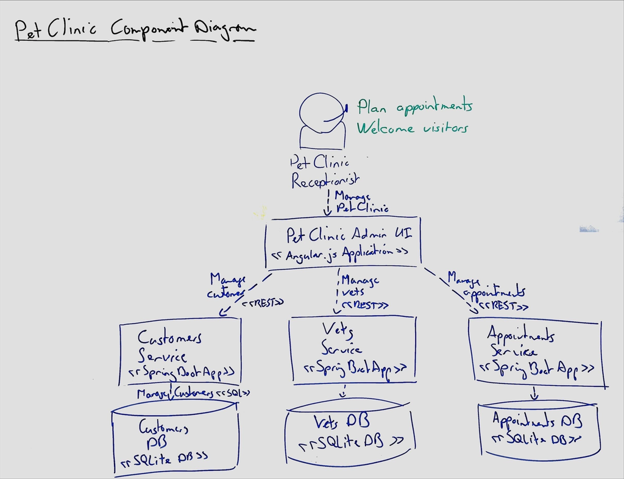

## Models

**Caseum adopts fact-based modelling for types**

- Capture just the key facts in designing your data models
- Decide the physical structure of your data as late as possible, focus on the logic first
- Add examples of facts to make the model clear

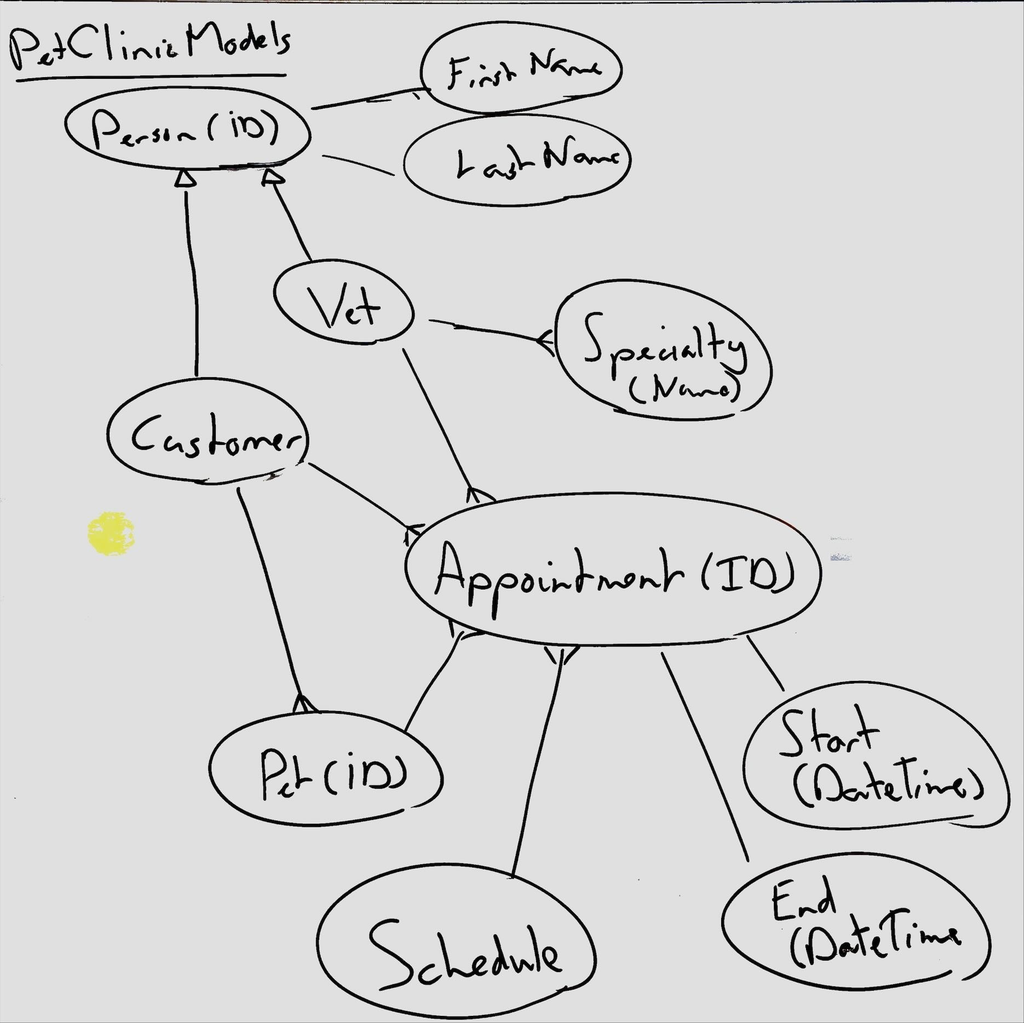

## Caseum

**The simplest software architecture approach that could possibly work**